# Risk Factor Analysis

## Outcome Variable

**Outcome Variable:** haz

## Predictor Variables

**Intervention Variable:** exclfeed6

**Adjustment Set:**

- arm
- sex
- brthmon
- W_mage
- meducyrs
- feducyrs
- hhwealth_quart
- hfoodsec
- W_mhtcm
- W_mwtkg
- W_mbmi
- vagbrth
- W_gagebrth
- W_birthwt
- W_birthlen
- W_nrooms
- W_nchldlt5
- month
- W_parity
- impfloor
- impsan
- safeh20
- delta_W_mage
- delta_meducyrs
- delta_feducyrs
- delta_hhwealth_quart
- delta_hfoodsec
- delta_W_mhtcm
- delta_W_mwtkg
- delta_W_mbmi
- delta_vagbrth
- delta_W_gagebrth
- delta_W_birthwt
- delta_W_birthlen
- delta_W_nrooms
- delta_W_nchldlt5
- delta_month
- delta_W_parity
- delta_impfloor
- delta_impsan
- delta_safeh20

## Stratifying Variables

The analysis was stratified on these variable(s):

- agecat
- studyid
- country

## Data Summary

| agecat | studyid | country | exclfeed6 | n_cell | n |
| --- | --- | --- | --- | --- | --- |
| Birth | ki0047075b-MAL-ED | BANGLADESH | 1 | 31 | 205 |
| Birth | ki0047075b-MAL-ED | BANGLADESH | 0 | 174 | 205 |
| Birth | ki0047075b-MAL-ED | BRAZIL | 1 | 2 | 60 |
| Birth | ki0047075b-MAL-ED | BRAZIL | 0 | 58 | 60 |
| Birth | ki0047075b-MAL-ED | INDIA | 1 | 1 | 39 |
| Birth | ki0047075b-MAL-ED | INDIA | 0 | 38 | 39 |
| Birth | ki0047075b-MAL-ED | NEPAL | 1 | 2 | 24 |
| Birth | ki0047075b-MAL-ED | NEPAL | 0 | 22 | 24 |
| Birth | ki0047075b-MAL-ED | PERU | 1 | 2 | 213 |
| Birth | ki0047075b-MAL-ED | PERU | 0 | 211 | 213 |
| Birth | ki0047075b-MAL-ED | SOUTH AFRICA | 1 | 0 | 91 |
| Birth | ki0047075b-MAL-ED | SOUTH AFRICA | 0 | 91 | 91 |
| Birth | ki0047075b-MAL-ED | TANZANIA, UNITED REPUBLIC OF | 1 | 0 | 113 |
| Birth | ki0047075b-MAL-ED | TANZANIA, UNITED REPUBLIC OF | 0 | 113 | 113 |
| Birth | ki1000108-CMC-V-BCS-2002 | INDIA | 1 | 7 | 7 |
| Birth | ki1000108-CMC-V-BCS-2002 | INDIA | 0 | 0 | 7 |
| Birth | ki1000108-IRC | INDIA | 1 | 0 | 14 |
| Birth | ki1000108-IRC | INDIA | 0 | 14 | 14 |
| Birth | ki1000109-EE | PAKISTAN | 1 | 38 | 42 |
| Birth | ki1000109-EE | PAKISTAN | 0 | 4 | 42 |
| Birth | ki1000304b-SAS-CompFeed | INDIA | 1 | 346 | 364 |
| Birth | ki1000304b-SAS-CompFeed | INDIA | 0 | 18 | 364 |
| Birth | ki1017093b-PROVIDE | BANGLADESH | 1 | 159 | 539 |
| Birth | ki1017093b-PROVIDE | BANGLADESH | 0 | 380 | 539 |
| Birth | ki1101329-Keneba | GAMBIA | 1 | 485 | 1403 |
| Birth | ki1101329-Keneba | GAMBIA | 0 | 918 | 1403 |
| Birth | ki1113344-GMS-Nepal | NEPAL | 1 | 419 | 563 |
| Birth | ki1113344-GMS-Nepal | NEPAL | 0 | 144 | 563 |
| Birth | kiGH5241-JiVitA-3 | BANGLADESH | 1 | 10452 | 13423 |
| Birth | kiGH5241-JiVitA-3 | BANGLADESH | 0 | 2971 | 13423 |

[output cut: 70 more lines]

The following strata were considered:

- agecat: 24 months, studyid: ki0047075b-MAL-ED, country: BANGLADESH
- agecat: 24 months, studyid: ki0047075b-MAL-ED, country: BRAZIL
- agecat: 24 months, studyid: ki0047075b-MAL-ED, country: INDIA
- agecat: 24 months, studyid: ki0047075b-MAL-ED, country: NEPAL
- agecat: 24 months, studyid: ki0047075b-MAL-ED, country: PERU
- agecat: 24 months, studyid: ki0047075b-MAL-ED, country: SOUTH AFRICA
- agecat: 24 months, studyid: ki0047075b-MAL-ED, country: TANZANIA, UNITED REPUBLIC OF
- agecat: 24 months, studyid: ki1000108-CMC-V-BCS-2002, country: INDIA
- agecat: 24 months, studyid: ki1000108-IRC, country: INDIA
- agecat: 24 months, studyid: ki1000109-EE, country: PAKISTAN
- agecat: 24 months, studyid: ki1017093b-PROVIDE, country: BANGLADESH
- agecat: 24 months, studyid: ki1101329-Keneba, country: GAMBIA
- agecat: 24 months, studyid: ki1113344-GMS-Nepal, country: NEPAL
- agecat: 24 months, studyid: ki1148112-LCNI-5, country: MALAWI
- agecat: 24 months, studyid: kiGH5241-JiVitA-3, country: BANGLADESH
- agecat: 24 months, studyid: kiGH5241-JiVitA-4, country: BANGLADESH
- agecat: 6 months, studyid: ki0047075b-MAL-ED, country: BANGLADESH
- agecat: 6 months, studyid: ki0047075b-MAL-ED, country: BRAZIL
- agecat: 6 months, studyid: ki0047075b-MAL-ED, country: INDIA
- agecat: 6 months, studyid: ki0047075b-MAL-ED, country: NEPAL
- agecat: 6 months, studyid: ki0047075b-MAL-ED, country: PERU
- agecat: 6 months, studyid: ki0047075b-MAL-ED, country: SOUTH AFRICA
- agecat: 6 months, studyid: ki0047075b-MAL-ED, country: TANZANIA, UNITED REPUBLIC OF
- agecat: 6 months, studyid: ki1000108-CMC-V-BCS-2002, country: INDIA
- agecat: 6 months, studyid: ki1000108-IRC, country: INDIA
- agecat: 6 months, studyid: ki1000109-EE, country: PAKISTAN
- agecat: 6 months, studyid: ki1000304b-SAS-CompFeed, country: INDIA
- agecat: 6 months, studyid: ki1000304b-SAS-FoodSuppl, country: INDIA
- agecat: 6 months, studyid: ki1017093b-PROVIDE, country: BANGLADESH
- agecat: 6 months, studyid: ki1101329-Keneba, country: GAMBIA
- agecat: 6 months, studyid: ki1113344-GMS-Nepal, country: NEPAL
- agecat: 6 months, studyid: ki1148112-LCNI-5, country: MALAWI
- agecat: 6 months, studyid: kiGH5241-JiVitA-3, country: BANGLADESH
- agecat: 6 months, studyid: kiGH5241-JiVitA-4, country: BANGLADESH
- agecat: Birth, studyid: ki0047075b-MAL-ED, country: BANGLADESH
- agecat: Birth, studyid: ki0047075b-MAL-ED, country: BRAZIL
- agecat: Birth, studyid: ki0047075b-MAL-ED, country: INDIA
- agecat: Birth, studyid: ki0047075b-MAL-ED, country: NEPAL
- agecat: Birth, studyid: ki0047075b-MAL-ED, country: PERU
- agecat: Birth, studyid: ki0047075b-MAL-ED, country: SOUTH AFRICA
- agecat: Birth, studyid: ki0047075b-MAL-ED, country: TANZANIA, UNITED REPUBLIC OF
- agecat: Birth, studyid: ki1000108-CMC-V-BCS-2002, country: INDIA
- agecat: Birth, studyid: ki1000108-IRC, country: INDIA
- agecat: Birth, studyid: ki1000109-EE, country: PAKISTAN
- agecat: Birth, studyid: ki1000304b-SAS-CompFeed, country: INDIA
- agecat: Birth, studyid: ki1017093b-PROVIDE, country: BANGLADESH
- agecat: Birth, studyid: ki1101329-Keneba, country: GAMBIA
- agecat: Birth, studyid: ki1113344-GMS-Nepal, country: NEPAL
- agecat: Birth, studyid: kiGH5241-JiVitA-3, country: BANGLADESH
- agecat: Birth, studyid: kiGH5241-JiVitA-4, country: BANGLADESH

### Dropped Strata

Some strata were dropped due to rare outcomes:

- agecat: Birth, studyid: ki0047075b-MAL-ED, country: BRAZIL
- agecat: Birth, studyid: ki0047075b-MAL-ED, country: INDIA
- agecat: Birth, studyid: ki0047075b-MAL-ED, country: NEPAL
- agecat: Birth, studyid: ki0047075b-MAL-ED, country: PERU
- agecat: Birth, studyid: ki0047075b-MAL-ED, country: SOUTH AFRICA
- agecat: Birth, studyid: ki0047075b-MAL-ED, country: TANZANIA, UNITED REPUBLIC OF
- agecat: Birth, studyid: ki1000108-CMC-V-BCS-2002, country: INDIA
- agecat: Birth, studyid: ki1000108-IRC, country: INDIA
- agecat: Birth, studyid: ki1000109-EE, country: PAKISTAN
- agecat: 6 months, studyid: ki0047075b-MAL-ED, country: INDIA
- agecat: 6 months, studyid: ki0047075b-MAL-ED, country: SOUTH AFRICA
- agecat: 6 months, studyid: ki0047075b-MAL-ED, country: TANZANIA, UNITED REPUBLIC OF
- agecat: 6 months, studyid: ki1000108-CMC-V-BCS-2002, country: INDIA
- agecat: 6 months, studyid: ki1000108-IRC, country: INDIA
- agecat: 6 months, studyid: ki1000304b-SAS-FoodSuppl, country: INDIA
- agecat: 24 months, studyid: ki0047075b-MAL-ED, country: INDIA
- agecat: 24 months, studyid: ki0047075b-MAL-ED, country: PERU
- agecat: 24 months, studyid: ki0047075b-MAL-ED, country: SOUTH AFRICA
- agecat: 24 months, studyid: ki0047075b-MAL-ED, country: TANZANIA, UNITED REPUBLIC OF
- agecat: 24 months, studyid: ki1000108-CMC-V-BCS-2002, country: INDIA
- agecat: 24 months, studyid: ki1000108-IRC, country: INDIA
- agecat: 24 months, studyid: ki1000109-EE, country: PAKISTAN

## Methods Detail

We’re interested in the causal parameters $E[Y_a]$ for all values of $a \in \mathcal{A}$. These parameters represent the mean outcome if, possibly contrary to fact, we intervened to set all units to have $A=a$. Under the randomization and positivity assumptions, these are identified by the statistical parameters $\psi_a=E_W[E_{Y|A,W}(Y|A=a,W)]$. In addition, we’re interested in the mean of $Y$, $E[Y]$ under no intervention (the observed mean). We will estimate these parameters by using SuperLearner to fit the relevant likelihood factors – $E_{Y|A,W}(Y|A=a,W)$ and $p(A=a|W)$, and then updating our likelihood fit using a joint TMLE.

For unadjusted analyses ($W=\{\}$), initial likelihoods were estimated using Lrnr_glm to estimate the simple $E(Y|A)$ and Lrnr_mean to estimate $p(A)$. For adjusted analyses, a small library containing Lrnr_glmnet, Lrnr_xgboost, and Lrnr_mean was used.

# Results Detail

## Results Plots

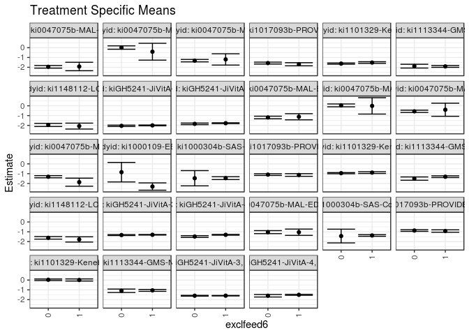

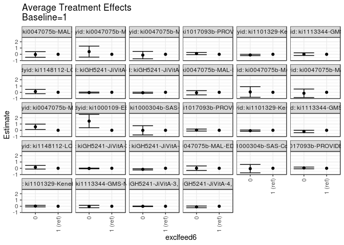

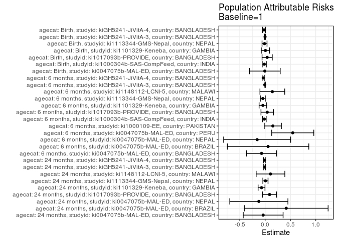

## Results Table

### Parameter: TSM

| agecat | studyid | country | intervention_level | baseline_level | estimate | ci_lower | ci_upper |
| --- | --- | --- | --- | --- | --- | --- | --- |
| Birth | ki0047075b-MAL-ED | BANGLADESH | 1 | NA | -1.0467925 | -1.3677499 | -0.7258351 |
| Birth | ki0047075b-MAL-ED | BANGLADESH | 0 | NA | -1.0373915 | -1.1908611 | -0.8839220 |
| Birth | ki1000304b-SAS-CompFeed | INDIA | 1 | NA | -1.3776197 | -1.4631704 | -1.2920690 |
| Birth | ki1000304b-SAS-CompFeed | INDIA | 0 | NA | -1.4364436 | -2.1366347 | -0.7362525 |
| Birth | ki1017093b-PROVIDE | BANGLADESH | 1 | NA | -0.9256868 | -1.0490210 | -0.8023526 |
| Birth | ki1017093b-PROVIDE | BANGLADESH | 0 | NA | -0.8735576 | -0.9600938 | -0.7870214 |
| Birth | ki1101329-Keneba | GAMBIA | 1 | NA | 0.0061415 | -0.1019044 | 0.1141874 |
| Birth | ki1101329-Keneba | GAMBIA | 0 | NA | 0.0291717 | -0.0503449 | 0.1086882 |
| Birth | ki1113344-GMS-Nepal | NEPAL | 1 | NA | -1.0526390 | -1.1497926 | -0.9554853 |
| Birth | ki1113344-GMS-Nepal | NEPAL | 0 | NA | -1.0941922 | -1.2688145 | -0.9195698 |
| Birth | kiGH5241-JiVitA-3 | BANGLADESH | 1 | NA | -1.5944469 | -1.6192336 | -1.5696601 |
| Birth | kiGH5241-JiVitA-3 | BANGLADESH | 0 | NA | -1.5991743 | -1.6384104 | -1.5599381 |
| Birth | kiGH5241-JiVitA-4 | BANGLADESH | 1 | NA | -1.5055088 | -1.5576290 | -1.4533885 |
| Birth | kiGH5241-JiVitA-4 | BANGLADESH | 0 | NA | -1.6013205 | -1.7294548 | -1.4731862 |
| 6 months | ki0047075b-MAL-ED | BANGLADESH | 1 | NA | -1.1197876 | -1.4339658 | -0.8056094 |
| 6 months | ki0047075b-MAL-ED | BANGLADESH | 0 | NA | -1.1939607 | -1.3256921 | -1.0622294 |
| 6 months | ki0047075b-MAL-ED | BRAZIL | 1 | NA | -0.0110750 | -0.8458409 | 0.8236909 |
| 6 months | ki0047075b-MAL-ED | BRAZIL | 0 | NA | 0.0406001 | -0.1046027 | 0.1858028 |
| 6 months | ki0047075b-MAL-ED | NEPAL | 1 | NA | -0.4050000 | -1.0737079 | 0.2637079 |
| 6 months | ki0047075b-MAL-ED | NEPAL | 0 | NA | -0.5658106 | -0.6826403 | -0.4489809 |
| 6 months | ki0047075b-MAL-ED | PERU | 1 | NA | -1.8680000 | -2.2794681 | -1.4565319 |
| 6 months | ki0047075b-MAL-ED | PERU | 0 | NA | -1.3117701 | -1.4224656 | -1.2010745 |
| 6 months | ki1000109-EE | PAKISTAN | 1 | NA | -2.3121318 | -2.6865239 | -1.9377397 |
| 6 months | ki1000109-EE | PAKISTAN | 0 | NA | -0.8473333 | -1.8424880 | 0.1478213 |
| 6 months | ki1000304b-SAS-CompFeed | INDIA | 1 | NA | -1.4549959 | -1.6008850 | -1.3091069 |
| 6 months | ki1000304b-SAS-CompFeed | INDIA | 0 | NA | -1.4654856 | -2.2428805 | -0.6880907 |
| 6 months | ki1017093b-PROVIDE | BANGLADESH | 1 | NA | -1.1337781 | -1.2681129 | -0.9994434 |
| 6 months | ki1017093b-PROVIDE | BANGLADESH | 0 | NA | -1.0955649 | -1.1835227 | -1.0076072 |
| 6 months | ki1101329-Keneba | GAMBIA | 1 | NA | -0.8891727 | -0.9793190 | -0.7990265 |
| 6 months | ki1101329-Keneba | GAMBIA | 0 | NA | -0.9492231 | -1.0081268 | -0.8903195 |
| 6 months | ki1113344-GMS-Nepal | NEPAL | 1 | NA | -1.3090067 | -1.3977996 | -1.2202138 |
| 6 months | ki1113344-GMS-Nepal | NEPAL | 0 | NA | -1.5002209 | -1.6673025 | -1.3331392 |
| 6 months | ki1148112-LCNI-5 | MALAWI | 1 | NA | -1.7824106 | -2.0519123 | -1.5129089 |
| 6 months | ki1148112-LCNI-5 | MALAWI | 0 | NA | -1.6209297 | -1.7518369 | -1.4900225 |
| 6 months | kiGH5241-JiVitA-3 | BANGLADESH | 1 | NA | -1.3072611 | -1.3376546 | -1.2768677 |
| 6 months | kiGH5241-JiVitA-3 | BANGLADESH | 0 | NA | -1.3361209 | -1.3854693 | -1.2867725 |
| 6 months | kiGH5241-JiVitA-4 | BANGLADESH | 1 | NA | -1.3107101 | -1.3515522 | -1.2698681 |
| 6 months | kiGH5241-JiVitA-4 | BANGLADESH | 0 | NA | -1.4842394 | -1.5738520 | -1.3946268 |
| 24 months | ki0047075b-MAL-ED | BANGLADESH | 1 | NA | -1.9192438 | -2.3493491 | -1.4891385 |
| 24 months | ki0047075b-MAL-ED | BANGLADESH | 0 | NA | -1.9489543 | -2.0835435 | -1.8143652 |
| 24 months | ki0047075b-MAL-ED | BRAZIL | 1 | NA | -0.4109249 | -1.2691992 | 0.4473493 |
| 24 months | ki0047075b-MAL-ED | BRAZIL | 0 | NA | 0.0155955 | -0.1570565 | 0.1882476 |
| 24 months | ki0047075b-MAL-ED | NEPAL | 1 | NA | -1.1950000 | -1.7707330 | -0.6192670 |
| 24 months | ki0047075b-MAL-ED | NEPAL | 0 | NA | -1.3216589 | -1.4457846 | -1.1975331 |
| 24 months | ki1017093b-PROVIDE | BANGLADESH | 1 | NA | -1.6902137 | -1.8470606 | -1.5333668 |
| 24 months | ki1017093b-PROVIDE | BANGLADESH | 0 | NA | -1.5693312 | -1.6651118 | -1.4735507 |
| 24 months | ki1101329-Keneba | GAMBIA | 1 | NA | -1.5170417 | -1.6004329 | -1.4336506 |
| 24 months | ki1101329-Keneba | GAMBIA | 0 | NA | -1.6233261 | -1.6884332 | -1.5582189 |
| 24 months | ki1113344-GMS-Nepal | NEPAL | 1 | NA | -1.9069117 | -2.0020415 | -1.8117819 |
| 24 months | ki1113344-GMS-Nepal | NEPAL | 0 | NA | -1.8833570 | -2.0773722 | -1.6893419 |
| 24 months | ki1148112-LCNI-5 | MALAWI | 1 | NA | -2.0715227 | -2.3727642 | -1.7702812 |
| 24 months | ki1148112-LCNI-5 | MALAWI | 0 | NA | -1.9534213 | -2.1117719 | -1.7950707 |
| 24 months | kiGH5241-JiVitA-3 | BANGLADESH | 1 | NA | -2.0018786 | -2.0418788 | -1.9618783 |
| 24 months | kiGH5241-JiVitA-3 | BANGLADESH | 0 | NA | -2.0460104 | -2.1153704 | -1.9766504 |
| 24 months | kiGH5241-JiVitA-4 | BANGLADESH | 1 | NA | -1.7773906 | -1.8195445 | -1.7352367 |
| 24 months | kiGH5241-JiVitA-4 | BANGLADESH | 0 | NA | -1.8443474 | -1.9249410 | -1.7637538 |

### Parameter: E(Y)

| agecat | studyid | country | intervention_level | baseline_level | estimate | ci_lower | ci_upper |
| --- | --- | --- | --- | --- | --- | --- | --- |
| Birth | ki0047075b-MAL-ED | BANGLADESH | NA | NA | -1.0530244 | -1.1913751 | -0.9146736 |
| Birth | ki1000304b-SAS-CompFeed | INDIA | NA | NA | -1.3937088 | -1.5095039 | -1.2779137 |
| Birth | ki1017093b-PROVIDE | BANGLADESH | NA | NA | -0.8851020 | -0.9601332 | -0.8100709 |
| Birth | ki1101329-Keneba | GAMBIA | NA | NA | 0.0126443 | -0.0554367 | 0.0807254 |
| Birth | ki1113344-GMS-Nepal | NEPAL | NA | NA | -1.0641208 | -1.1525364 | -0.9757052 |
| Birth | kiGH5241-JiVitA-3 | BANGLADESH | NA | NA | -1.5955338 | -1.6186322 | -1.5724354 |
| Birth | kiGH5241-JiVitA-4 | BANGLADESH | NA | NA | -1.5273138 | -1.5765339 | -1.4780937 |
| 6 months | ki0047075b-MAL-ED | BANGLADESH | NA | NA | -1.1900794 | -1.3096296 | -1.0705291 |
| 6 months | ki0047075b-MAL-ED | BRAZIL | NA | NA | 0.0475758 | -0.0963508 | 0.1915023 |
| 6 months | ki0047075b-MAL-ED | NEPAL | NA | NA | -0.5622370 | -0.6774081 | -0.4470660 |
| 6 months | ki0047075b-MAL-ED | PERU | NA | NA | -1.3220326 | -1.4308168 | -1.2132484 |
| 6 months | ki1000109-EE | PAKISTAN | NA | NA | -2.1595486 | -2.5331781 | -1.7859192 |
| 6 months | ki1000304b-SAS-CompFeed | INDIA | NA | NA | -1.4697236 | -1.6333919 | -1.3060553 |
| 6 months | ki1017093b-PROVIDE | BANGLADESH | NA | NA | -1.0916915 | -1.1661176 | -1.0172654 |
| 6 months | ki1101329-Keneba | GAMBIA | NA | NA | -0.9331108 | -0.9823173 | -0.8839043 |
| 6 months | ki1113344-GMS-Nepal | NEPAL | NA | NA | -1.3540280 | -1.4334801 | -1.2745760 |
| 6 months | ki1148112-LCNI-5 | MALAWI | NA | NA | -1.6395956 | -1.7592633 | -1.5199278 |
| 6 months | kiGH5241-JiVitA-3 | BANGLADESH | NA | NA | -1.3138259 | -1.3418712 | -1.2857806 |
| 6 months | kiGH5241-JiVitA-4 | BANGLADESH | NA | NA | -1.3482303 | -1.3866421 | -1.3098185 |
| 24 months | ki0047075b-MAL-ED | BANGLADESH | NA | NA | -1.9576341 | -2.0857597 | -1.8295086 |
| 24 months | ki0047075b-MAL-ED | BRAZIL | NA | NA | 0.0061144 | -0.1625850 | 0.1748138 |
| 24 months | ki0047075b-MAL-ED | NEPAL | NA | NA | -1.3187671 | -1.4406685 | -1.1968657 |
| 24 months | ki1017093b-PROVIDE | BANGLADESH | NA | NA | -1.6024221 | -1.6857420 | -1.5191023 |
| 24 months | ki1101329-Keneba | GAMBIA | NA | NA | -1.5876293 | -1.6406755 | -1.5345831 |
| 24 months | ki1113344-GMS-Nepal | NEPAL | NA | NA | -1.9002128 | -1.9869255 | -1.8135001 |
| 24 months | ki1148112-LCNI-5 | MALAWI | NA | NA | -1.9651323 | -2.1053230 | -1.8249415 |
| 24 months | kiGH5241-JiVitA-3 | BANGLADESH | NA | NA | -2.0118003 | -2.0479952 | -1.9756055 |
| 24 months | kiGH5241-JiVitA-4 | BANGLADESH | NA | NA | -1.7914765 | -1.8297816 | -1.7531715 |

### Parameter: ATE

| agecat | studyid | country | intervention_level | baseline_level | estimate | ci_lower | ci_upper |
| --- | --- | --- | --- | --- | --- | --- | --- |
| Birth | ki0047075b-MAL-ED | BANGLADESH | 1 | 1 | 0.0000000 | 0.0000000 | 0.0000000 |
| Birth | ki0047075b-MAL-ED | BANGLADESH | 0 | 1 | 0.0094010 | -0.3470198 | 0.3658218 |
| Birth | ki1000304b-SAS-CompFeed | INDIA | 1 | 1 | 0.0000000 | 0.0000000 | 0.0000000 |
| Birth | ki1000304b-SAS-CompFeed | INDIA | 0 | 1 | -0.0588239 | -0.7253365 | 0.6076887 |
| Birth | ki1017093b-PROVIDE | BANGLADESH | 1 | 1 | 0.0000000 | 0.0000000 | 0.0000000 |
| Birth | ki1017093b-PROVIDE | BANGLADESH | 0 | 1 | 0.0521292 | -0.0833484 | 0.1876069 |
| Birth | ki1101329-Keneba | GAMBIA | 1 | 1 | 0.0000000 | 0.0000000 | 0.0000000 |
| Birth | ki1101329-Keneba | GAMBIA | 0 | 1 | 0.0230301 | -0.1012684 | 0.1473287 |
| Birth | ki1113344-GMS-Nepal | NEPAL | 1 | 1 | 0.0000000 | 0.0000000 | 0.0000000 |
| Birth | ki1113344-GMS-Nepal | NEPAL | 0 | 1 | -0.0415532 | -0.2335042 | 0.1503977 |
| Birth | kiGH5241-JiVitA-3 | BANGLADESH | 1 | 1 | 0.0000000 | 0.0000000 | 0.0000000 |
| Birth | kiGH5241-JiVitA-3 | BANGLADESH | 0 | 1 | -0.0047274 | -0.0454231 | 0.0359683 |
| Birth | kiGH5241-JiVitA-4 | BANGLADESH | 1 | 1 | 0.0000000 | 0.0000000 | 0.0000000 |
| Birth | kiGH5241-JiVitA-4 | BANGLADESH | 0 | 1 | -0.0958117 | -0.2333646 | 0.0417411 |
| 6 months | ki0047075b-MAL-ED | BANGLADESH | 1 | 1 | 0.0000000 | 0.0000000 | 0.0000000 |
| 6 months | ki0047075b-MAL-ED | BANGLADESH | 0 | 1 | -0.0741731 | -0.4154289 | 0.2670827 |
| 6 months | ki0047075b-MAL-ED | BRAZIL | 1 | 1 | 0.0000000 | 0.0000000 | 0.0000000 |
| 6 months | ki0047075b-MAL-ED | BRAZIL | 0 | 1 | 0.0516750 | -0.7962745 | 0.8996245 |
| 6 months | ki0047075b-MAL-ED | NEPAL | 1 | 1 | 0.0000000 | 0.0000000 | 0.0000000 |
| 6 months | ki0047075b-MAL-ED | NEPAL | 0 | 1 | -0.1608106 | -0.8396474 | 0.5180262 |
| 6 months | ki0047075b-MAL-ED | PERU | 1 | 1 | 0.0000000 | 0.0000000 | 0.0000000 |
| 6 months | ki0047075b-MAL-ED | PERU | 0 | 1 | 0.5562299 | 0.1301320 | 0.9823279 |
| 6 months | ki1000109-EE | PAKISTAN | 1 | 1 | 0.0000000 | 0.0000000 | 0.0000000 |
| 6 months | ki1000109-EE | PAKISTAN | 0 | 1 | 1.4647984 | 0.4015477 | 2.5280492 |
| 6 months | ki1000304b-SAS-CompFeed | INDIA | 1 | 1 | 0.0000000 | 0.0000000 | 0.0000000 |
| 6 months | ki1000304b-SAS-CompFeed | INDIA | 0 | 1 | -0.0104897 | -0.7471588 | 0.7261794 |
| 6 months | ki1017093b-PROVIDE | BANGLADESH | 1 | 1 | 0.0000000 | 0.0000000 | 0.0000000 |
| 6 months | ki1017093b-PROVIDE | BANGLADESH | 0 | 1 | 0.0382132 | -0.1226025 | 0.1990290 |
| 6 months | ki1101329-Keneba | GAMBIA | 1 | 1 | 0.0000000 | 0.0000000 | 0.0000000 |
| 6 months | ki1101329-Keneba | GAMBIA | 0 | 1 | -0.0600504 | -0.1667736 | 0.0466728 |
| 6 months | ki1113344-GMS-Nepal | NEPAL | 1 | 1 | 0.0000000 | 0.0000000 | 0.0000000 |
| 6 months | ki1113344-GMS-Nepal | NEPAL | 0 | 1 | -0.1912142 | -0.3794047 | -0.0030236 |
| 6 months | ki1148112-LCNI-5 | MALAWI | 1 | 1 | 0.0000000 | 0.0000000 | 0.0000000 |
| 6 months | ki1148112-LCNI-5 | MALAWI | 0 | 1 | 0.1614809 | -0.1328874 | 0.4558493 |
| 6 months | kiGH5241-JiVitA-3 | BANGLADESH | 1 | 1 | 0.0000000 | 0.0000000 | 0.0000000 |
| 6 months | kiGH5241-JiVitA-3 | BANGLADESH | 0 | 1 | -0.0288597 | -0.0812313 | 0.0235118 |
| 6 months | kiGH5241-JiVitA-4 | BANGLADESH | 1 | 1 | 0.0000000 | 0.0000000 | 0.0000000 |
| 6 months | kiGH5241-JiVitA-4 | BANGLADESH | 0 | 1 | -0.1735293 | -0.2706771 | -0.0763814 |
| 24 months | ki0047075b-MAL-ED | BANGLADESH | 1 | 1 | 0.0000000 | 0.0000000 | 0.0000000 |
| 24 months | ki0047075b-MAL-ED | BANGLADESH | 0 | 1 | -0.0297105 | -0.4790890 | 0.4196681 |
| 24 months | ki0047075b-MAL-ED | BRAZIL | 1 | 1 | 0.0000000 | 0.0000000 | 0.0000000 |
| 24 months | ki0047075b-MAL-ED | BRAZIL | 0 | 1 | 0.4265205 | -0.4508357 | 1.3038767 |
| 24 months | ki0047075b-MAL-ED | NEPAL | 1 | 1 | 0.0000000 | 0.0000000 | 0.0000000 |
| 24 months | ki0047075b-MAL-ED | NEPAL | 0 | 1 | -0.1266589 | -0.7156204 | 0.4623026 |
| 24 months | ki1017093b-PROVIDE | BANGLADESH | 1 | 1 | 0.0000000 | 0.0000000 | 0.0000000 |
| 24 months | ki1017093b-PROVIDE | BANGLADESH | 0 | 1 | 0.1208824 | -0.0599299 | 0.3016948 |
| 24 months | ki1101329-Keneba | GAMBIA | 1 | 1 | 0.0000000 | 0.0000000 | 0.0000000 |
| 24 months | ki1101329-Keneba | GAMBIA | 0 | 1 | -0.1062843 | -0.2083235 | -0.0042451 |
| 24 months | ki1113344-GMS-Nepal | NEPAL | 1 | 1 | 0.0000000 | 0.0000000 | 0.0000000 |
| 24 months | ki1113344-GMS-Nepal | NEPAL | 0 | 1 | 0.0235546 | -0.1897628 | 0.2368721 |
| 24 months | ki1148112-LCNI-5 | MALAWI | 1 | 1 | 0.0000000 | 0.0000000 | 0.0000000 |
| 24 months | ki1148112-LCNI-5 | MALAWI | 0 | 1 | 0.1181014 | -0.2239224 | 0.4601251 |
| 24 months | kiGH5241-JiVitA-3 | BANGLADESH | 1 | 1 | 0.0000000 | 0.0000000 | 0.0000000 |
| 24 months | kiGH5241-JiVitA-3 | BANGLADESH | 0 | 1 | -0.0441318 | -0.1206602 | 0.0323965 |
| 24 months | kiGH5241-JiVitA-4 | BANGLADESH | 1 | 1 | 0.0000000 | 0.0000000 | 0.0000000 |
| 24 months | kiGH5241-JiVitA-4 | BANGLADESH | 0 | 1 | -0.0669568 | -0.1532746 | 0.0193610 |

### Parameter: PAR

| agecat | studyid | country | intervention_level | baseline_level | estimate | ci_lower | ci_upper |
| --- | --- | --- | --- | --- | --- | --- | --- |
| Birth | ki0047075b-MAL-ED | BANGLADESH | 1 | NA | -0.0062319 | -0.3106795 | 0.2982157 |
| Birth | ki1000304b-SAS-CompFeed | INDIA | 1 | NA | -0.0160891 | -0.0566754 | 0.0244973 |
| Birth | ki1017093b-PROVIDE | BANGLADESH | 1 | NA | 0.0405848 | -0.0601995 | 0.1413691 |
| Birth | ki1101329-Keneba | GAMBIA | 1 | NA | 0.0065028 | -0.0752536 | 0.0882592 |
| Birth | ki1113344-GMS-Nepal | NEPAL | 1 | NA | -0.0114818 | -0.0606591 | 0.0376954 |
| Birth | kiGH5241-JiVitA-3 | BANGLADESH | 1 | NA | -0.0010869 | -0.0101117 | 0.0079379 |
| Birth | kiGH5241-JiVitA-4 | BANGLADESH | 1 | NA | -0.0218051 | -0.0504725 | 0.0068624 |
| 6 months | ki0047075b-MAL-ED | BANGLADESH | 1 | NA | -0.0702918 | -0.3675836 | 0.2270001 |
| 6 months | ki0047075b-MAL-ED | BRAZIL | 1 | NA | 0.0586507 | -0.7456351 | 0.8629366 |
| 6 months | ki0047075b-MAL-ED | NEPAL | 1 | NA | -0.1572370 | -0.8191102 | 0.5046361 |
| 6 months | ki0047075b-MAL-ED | PERU | 1 | NA | 0.5459674 | 0.1304259 | 0.9615089 |
| 6 months | ki1000109-EE | PAKISTAN | 1 | NA | 0.1525832 | -0.0166253 | 0.3217916 |
| 6 months | ki1000304b-SAS-CompFeed | INDIA | 1 | NA | -0.0147277 | -0.0507565 | 0.0213012 |
| 6 months | ki1017093b-PROVIDE | BANGLADESH | 1 | NA | 0.0420866 | -0.0817146 | 0.1658879 |
| 6 months | ki1101329-Keneba | GAMBIA | 1 | NA | -0.0439381 | -0.1189087 | 0.0310326 |
| 6 months | ki1113344-GMS-Nepal | NEPAL | 1 | NA | -0.0450213 | -0.0939223 | 0.0038797 |
| 6 months | ki1148112-LCNI-5 | MALAWI | 1 | NA | 0.1428150 | -0.1020138 | 0.3876438 |
| 6 months | kiGH5241-JiVitA-3 | BANGLADESH | 1 | NA | -0.0065647 | -0.0185750 | 0.0054456 |
| 6 months | kiGH5241-JiVitA-4 | BANGLADESH | 1 | NA | -0.0375202 | -0.0590381 | -0.0160023 |
| 24 months | ki0047075b-MAL-ED | BANGLADESH | 1 | NA | -0.0383903 | -0.4320180 | 0.3552373 |
| 24 months | ki0047075b-MAL-ED | BRAZIL | 1 | NA | 0.4170393 | -0.4102789 | 1.2443576 |
| 24 months | ki0047075b-MAL-ED | NEPAL | 1 | NA | -0.1237671 | -0.6980101 | 0.4504758 |
| 24 months | ki1017093b-PROVIDE | BANGLADESH | 1 | NA | 0.0877915 | -0.0504934 | 0.2260765 |
| 24 months | ki1101329-Keneba | GAMBIA | 1 | NA | -0.0705876 | -0.1385172 | -0.0026579 |
| 24 months | ki1113344-GMS-Nepal | NEPAL | 1 | NA | 0.0066989 | -0.0443505 | 0.0577483 |
| 24 months | ki1148112-LCNI-5 | MALAWI | 1 | NA | 0.1063904 | -0.1769620 | 0.3897428 |
| 24 months | kiGH5241-JiVitA-3 | BANGLADESH | 1 | NA | -0.0099217 | -0.0276123 | 0.0077688 |
| 24 months | kiGH5241-JiVitA-4 | BANGLADESH | 1 | NA | -0.0140859 | -0.0321149 | 0.0039430 |